# Assignment 1: Classic ARIMA modelling approach

###### Álvaro Capel & Enric Alavedra

### GDPUSAvar: Gross Domestic Product variation in USA

##### 1) If we propose an ARMA(2,0) model and an ARMA(1,1), the second is a better model.

**Answer**: *FALSE*. The comparison has to be based on AIC and BIC as both models have the same number of parameters. The ARMA(2,0) achieves a little bit lower values for both AIC and BIC, meaning it fits the data better with equal complexity. Nevertheless, we consider it is not enough to confirm ourt decision and that is why we have used the Ljung-Box test to confirm that residuals of both models have equall noise (that is, equall complexity). As confirmed, both models can be compared without missing information.

```r
library(forecast)
library(lmtest)
serie_GDPUSAvar=ts((read.table("datasets/gdpusavar.dat",header=F)),start=1990,freq=4)

# QUESTION 1 JUSTIFICATION
# Loading the models
fit_ar2=arima(serie_GDPUSAvar, order = c(2,0,0))
fit_arma=arima(serie_GDPUSAvar, order = c(1,0,1))
# Coefficients and significance
cat("ARMA(2,0):\n"); coeftest(fit_ar2)
```

```
## ARMA(2,0):
```

```
##
## z test of coefficients:
##
##           Estimate Std. Error z value  Pr(>|z|)
## ar1       0.304756   0.089322  3.4119 0.0006452 ***
## ar2       0.194185   0.089200  2.1770 0.0294832 *
## intercept 2.497980   0.381414  6.5493 5.782e-11 ***
## ---
## Signif. codes:  0 '***' 0.001 '**' 0.01 '*' 0.05 '.' 0.1 ' ' 1
```

```r
cat("ARMA(1,1):\n "); coeftest(fit_arma)
```

```
## ARMA(1,1):
##
```

```
##
## z test of coefficients:
##
##           Estimate Std. Error z value  Pr(>|z|)
## ar1        0.70078    0.13571  5.1638 2.421e-07 ***
## ma1       -0.37885    0.17472 -2.1684   0.03013 *
## intercept  2.49165    0.39707  6.2750 3.495e-10 ***
## ---
## Signif. codes:  0 '***' 0.001 '**' 0.01 '*' 0.05 '.' 0.1 ' ' 1
```

```r
# AIC / BIC comparison
comparison=data.frame(
  Model  = c("ARMA(2,0)", "ARMA(1,1)"),
  AIC    = c(AIC(fit_ar2),  AIC(fit_arma)),
  BIC    = c(BIC(fit_ar2),  BIC(fit_arma))
)
comparison
```

| Model | AIC | BIC |
| --- | --- | --- |
| ARMA(2,0) | 528.8251 | 539.9751 |
| ARMA(1,1) | 529.6305 | 540.7804 |

```r
# Ljung-Box on residuals
Box.test(residuals(fit_ar2),  lag = 10, type = "Ljung-Box", fitdf = 2)
```

```
##
##  Box-Ljung test
##
## data:  residuals(fit_ar2)
## X-squared = 9.7972, df = 8, p-value = 0.2796
```

```r
Box.test(residuals(fit_arma), lag = 10, type = "Ljung-Box", fitdf = 2)
```

```
##
##  Box-Ljung test
##
## data:  residuals(fit_arma)
## X-squared = 9.1617, df = 8, p-value = 0.3288
```

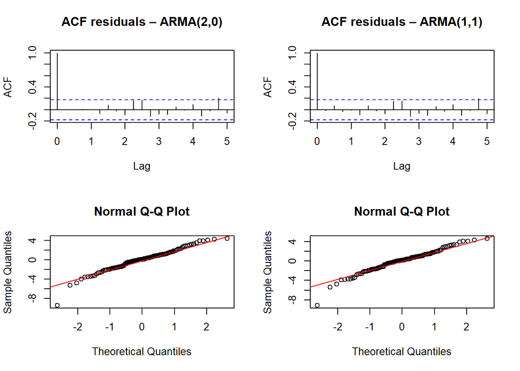

```r
# Residual diagnostics
par(mfrow = c(2,2))
acf(residuals(fit_ar2),  main = "ACF residuals – ARMA(2,0)")
acf(residuals(fit_arma), main = "ACF residuals – ARMA(1,1)")
qqnorm(residuals(fit_ar2));  qqline(residuals(fit_ar2),  col = "red")
qqnorm(residuals(fit_arma)); qqline(residuals(fit_arma), col = "red")
```

```r
par(mfrow = c(1,1))
```

##### 2) The fitted ARMA(1,1) model is stationary and invertible.

**Answer**: *TRUE*. In order to justify this answer we have to check if phi is, in absolute value, lower than 1 to confirm stationary process. On the other hand, checking if theta is lower than one it is necessary for inversion. As both conditions are accomplished, we can affirm the statement it is true.

```r
# QUESTION 2 JUSTIFICATION
phi1=coef(fit_arma)["ar1"]
theta1=coef(fit_arma)["ma1"]

cat("phi1   =", round(phi1,   4), "\n")
```

```
## phi1   = 0.7008
```

```r
cat("theta1 =", round(theta1, 4))
```

```
## theta1 = -0.3789
```

### EURODOL: Monthly Average Dollar/Euro exchange rate

##### 3) Although the mean appears to be non-constant, valid stationary-ARMA models could be fitted to the original series

**Answer**: *FALSE*. At first, when plotting the monthly average exchange rate it can be easily extracted that the mean is not constant over time, meaning that the stationarity assumption of the ARMA models is not followed. But also, the ACF decays so slowly, meaning it is significant for many lags, and that’s typical of a unit root. Indeed, when making the hypothesis testing of the unit root (meaning that the series won’t be stationary), we are obtaining a p-value greater than 0.05 and we can not reject the null hypothesis.

```r
library(tseries)
```

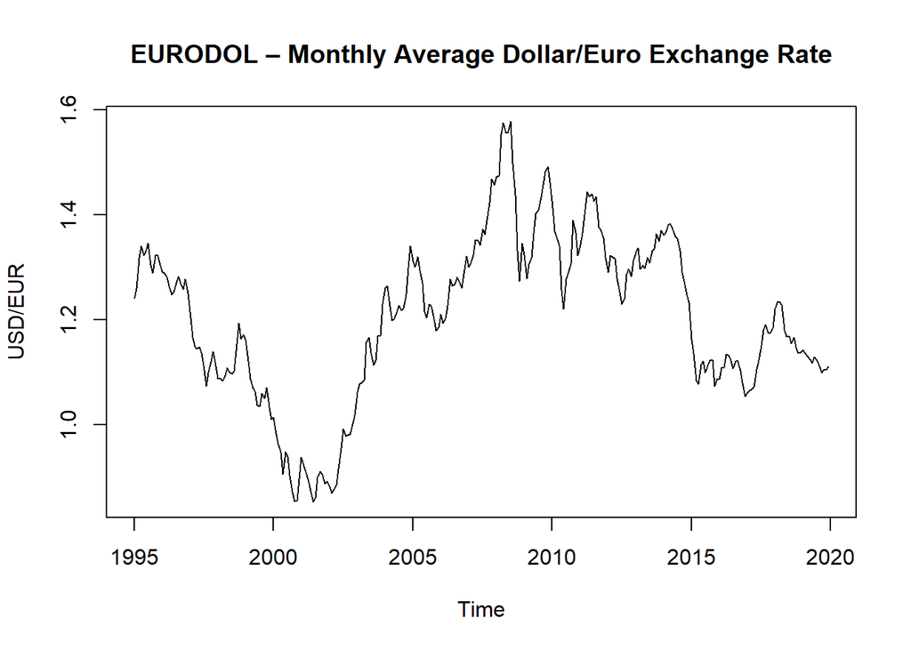

```r
serie_EURODOL=ts(as.numeric(unlist(read.table("datasets/eurodol.dat"))),
                    start = 1995, freq = 12)
# QUESTION 3 JUSTIFIACTION
# Visual inspection
plot(serie_EURODOL,
     main = "EURODOL – Monthly Average Dollar/Euro Exchange Rate",
     ylab = "USD/EUR", xlab = "Time")
```

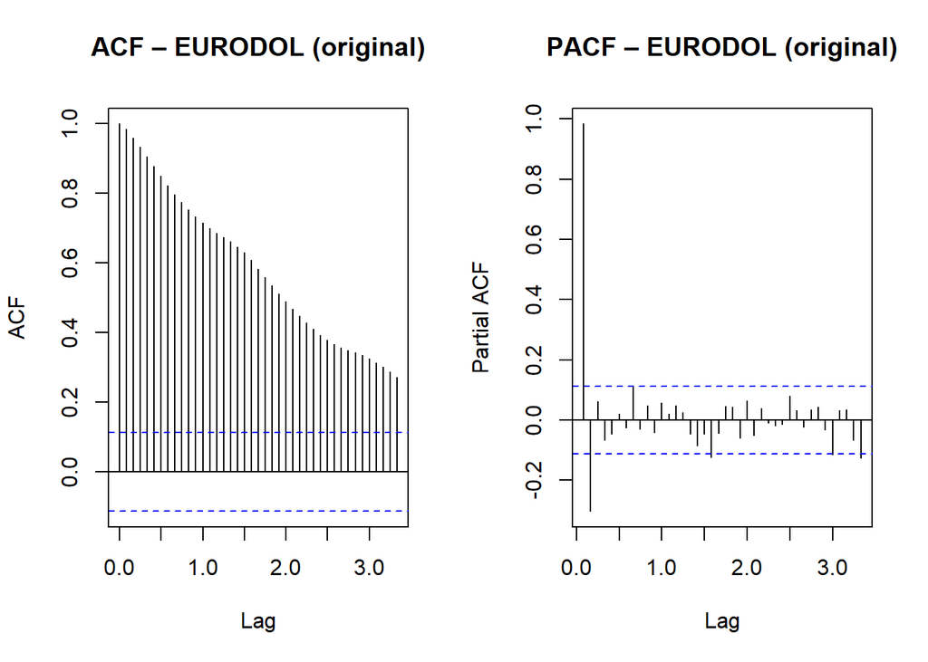

```r
# ACF of the original series
par(mfrow = c(1,2))
acf(serie_EURODOL,  lag.max = 40, main = "ACF – EURODOL (original)")
pacf(serie_EURODOL, lag.max = 40, main = "PACF – EURODOL (original)")
```

```r
par(mfrow = c(1,1))
# ADF test on original series
adf.test(serie_EURODOL)
```

```
##
##  Augmented Dickey-Fuller Test
##
## data:  serie_EURODOL
## Dickey-Fuller = -2.2211, Lag order = 6, p-value = 0.4831
## alternative hypothesis: stationary
```

### PreuIndEner: Monthly Energy Price in Industry in Spain

##### 4) This monthly series has a seasonal component. Therefore, for the original series, we need to identify both a regular and a seasonal part for the model.

**Answer**: *TRUE*. To justify this answer, at first, we have validated using graphs if there is a seasonal component. Looking at the figures, it seems there it is. Once done, we have derived both the seasonal and the regular components.

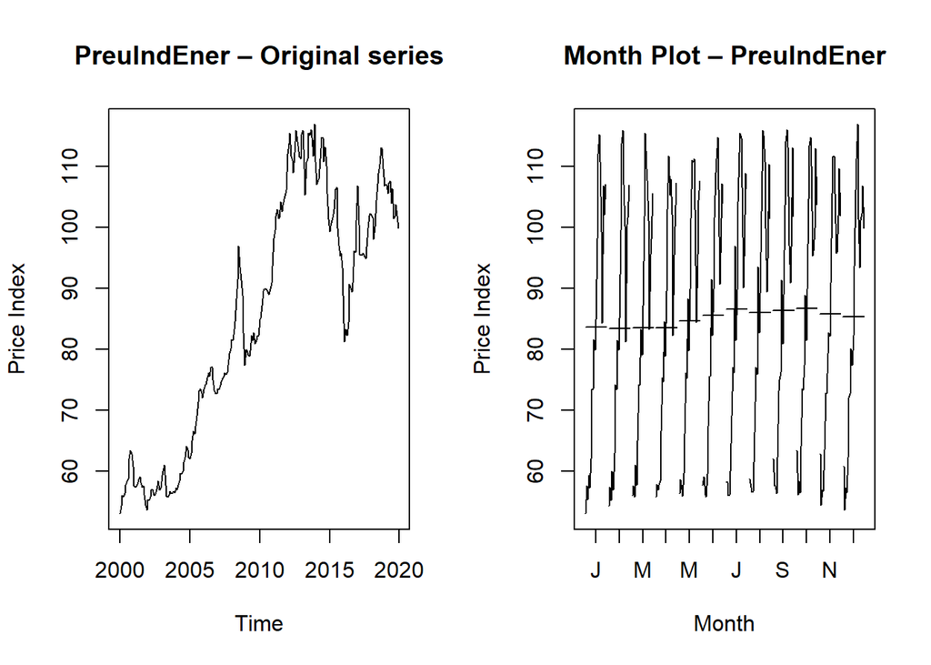

```r
serie_preuINDENER=ts(read.table("datasets/preuIndEner.dat"),start=2000,freq=12)

# QUESTION 4 JUSTIFICATION
# Is there a seasonal component?
par(mfrow = c(1,2))
plot(serie_preuINDENER,
     main = "PreuIndEner – Original series",
     ylab = "Price Index", xlab = "Time")
monthplot(serie_preuINDENER,
          main = "Month Plot – PreuIndEner",
          ylab = "Price Index", xlab = "Month")
```

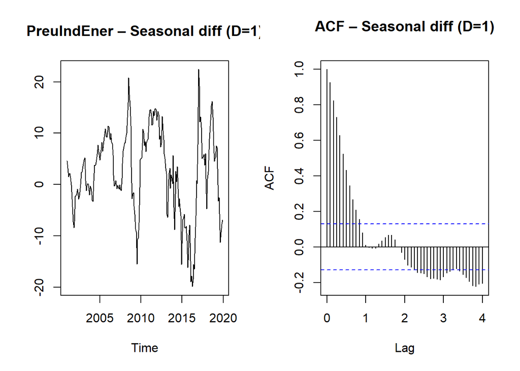

```r
par(mfrow = c(1,1))

# Calculation of both parts for original series
# SEASONAL DIFFERENCE (d=1)
d12=diff(serie_preuINDENER, lag = 12)
par(mfrow = c(1,2))
plot(d12, main = "PreuIndEner – Seasonal diff (D=1)", ylab = "", xlab = "Time")
acf(d12,  lag.max = 48, main = "ACF – Seasonal diff (D=1)")
```

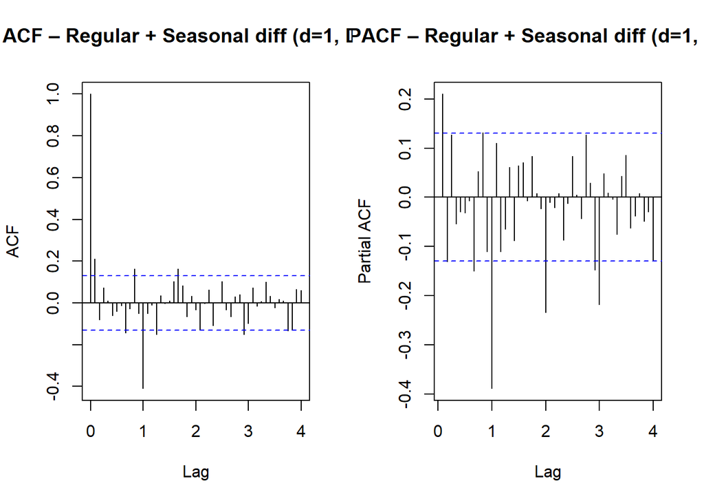

```r
par(mfrow = c(1,1))
# REGULAR DIFFERENCE (d=1)
d1d12=diff(d12, lag = 1)
par(mfrow = c(1,2))
acf(d1d12,  lag.max = 48, main = "ACF – Regular + Seasonal diff (d=1, D=1)")
pacf(d1d12, lag.max = 48, main = "PACF – Regular + Seasonal diff (d=1, D=1)")
```

```r
par(mfrow = c(1,1))
```

### EURIBOR: Euro Interbank Offered Rate

##### 5) It seems that two regular differencings are needed to transform the series into a stationary one.

**Answer**: *TRUE*. We see clearly how the series becomes more stationary after 2 differentiations. Moreover when comparing the variances after differentiating, we don’t see that the variance after the second diff increases the variance of the first diff, indicating that the second diff was indeed needed

```r
serie_EURIBOR=ts((read.table("datasets/euribor.dat")),start=1999,freq=12)
serie_EURIBOR=log(serie_EURIBOR+1)

# QUESTION 5 JUSTIFICATION
var(serie_EURIBOR)
```

```
##           V1
## V1 0.4601053
```

```r
d1=diff(serie_EURIBOR)
var(d1)
```

```
##             V1
## V1 0.001564921
```

```r
d2=diff(d1)
var(d2)
```

```
##             V1
## V1 0.001006835
```

##### 6) The once-differenced (d=1) log-transformed-series has a non-significant mean. Thus, when fitting an AR(1) process, it is always better to drop this parameter (intercept) from the model.

```r
# QUESTION 6 JUSTIFICATION
log_euribor=log(serie_EURIBOR)
d1_log_euribor=diff(log_euribor)
t.test(d1_log_euribor, mu = 0)
```

```
##
##  One Sample t-test
##
## data:  d1_log_euribor
## t = -3.9372, df = 203, p-value = 0.0001133
## alternative hypothesis: true mean is not equal to 0
## 95 percent confidence interval:
##  -0.025957734 -0.008634378
## sample estimates:
##   mean of x
## -0.01729606
```

```r
fit_with=arima(d1_log_euribor, order = c(1,0,0), include.mean = TRUE)
fit_without=arima(d1_log_euribor, order = c(1,0,0), include.mean = FALSE)
cat("AR(1) including the mean: \n");    print(fit_with)
```

```
## AR(1) including the mean:
```

```
##
## Call:
## arima(x = d1_log_euribor, order = c(1, 0, 0), include.mean = TRUE)
##
## Coefficients:
##          ar1  intercept
##       0.7726    -0.0222
## s.e.  0.0506     0.0131
##
## sigma^2 estimated as 0.001843:  log likelihood = 352.32,  aic = -698.64
```

```r
cat("AIC:", AIC(fit_with), "| BIC:", BIC(fit_with), "\n")
```

```
## AIC: -698.644 | BIC: -688.6896
```

```r
cat("AR(1) not including the mean: \n"); print(fit_without)
```

```
## AR(1) not including the mean:
```

```
##
## Call:
## arima(x = d1_log_euribor, order = c(1, 0, 0), include.mean = FALSE)
##
## Coefficients:
##          ar1
##       0.7941
## s.e.  0.0491
##
## sigma^2 estimated as 0.001867:  log likelihood = 350.97,  aic = -697.95
```

```r
cat("AIC:", AIC(fit_without), "| BIC:", BIC(fit_without), "\n")
```

```
## AIC: -697.9467 | BIC: -691.3104
```

##### 7) When fitting an ARIMA(0, 2, 5) model to the original series, the residuals are reasonably well behaved and thus we validate the model

```r
# QUESTION 7 JUSTIFICATION
fit_011=arima(serie_EURIBOR, order = c(0,1,1))  # Correct initial model to be compared
fit_025=arima(serie_EURIBOR, order = c(0,2,5))

cat("ARIMA(0,2,5): \n"); print(fit_025)
```

```
## ARIMA(0,2,5):
```

```
##
## Call:
## arima(x = serie_EURIBOR, order = c(0, 2, 5))
##
## Coefficients:
##           ma1      ma2      ma3      ma4      ma5
##       -0.2914  -0.2959  -0.1198  -0.1168  -0.1760
## s.e.   0.0750   0.0722   0.0778   0.0744   0.0664
##
## sigma^2 estimated as 0.0008378:  log likelihood = 528.72,  aic = -1045.45
```

```r
cat("AIC:", AIC(fit_025), "| BIC:", BIC(fit_025), "\n")
```

```
## AIC: -1045.449 | BIC: -1024.321
```

```r
cat("ARIMA(0,1,1): \n"); print(fit_011)
```

```
## ARIMA(0,1,1):
```

```
##
## Call:
## arima(x = serie_EURIBOR, order = c(0, 1, 1))
##
## Coefficients:
##          ma1
##       0.6015
## s.e.  0.0419
##
## sigma^2 estimated as 0.0009955:  log likelihood = 511.11,  aic = -1018.22
```

```r
cat("AIC:", AIC(fit_011), "| BIC:", BIC(fit_011), "\n")
```

```
## AIC: -1018.217 | BIC: -1011.166
```

```r
cat("Ljung-Box – ARIMA(0,2,5): \n")
```

```
## Ljung-Box – ARIMA(0,2,5):
```

```r
print(Box.test(residuals(fit_025), lag = 15, type = "Ljung-Box", fitdf = 5))
```

```
##
##  Box-Ljung test
##
## data:  residuals(fit_025)
## X-squared = 8.6872, df = 10, p-value = 0.562
```

```r
cat("Ljung-Box – ARIMA(0,1,1): \n")
```

```
## Ljung-Box – ARIMA(0,1,1):
```

```r
print(Box.test(residuals(fit_011), lag = 15, type = "Ljung-Box", fitdf = 1))
```

```
##
##  Box-Ljung test
##
## data:  residuals(fit_011)
## X-squared = 64.015, df = 14, p-value = 2.292e-08
```

### Atur: Unemployed registered people in Spain

##### 8) For the log-transformed series, the ARIMA(1,1,1)(0,1,1)12 model is better than the ARIMA(0,2,1)(0,1,1)12 model.

**Answer**: *TRUE*. The justification is derived based on the information criteria: when comparing the AIC and the BIC of both models, we see that the ARIMA(0,2,1)(0,1,1)12 model performs worse than ARIMA(1,1,1)(0,1,1)12 model.

```r
serie_atur=window(ts(read.table("datasets/atur.dat")/1000,start=1996,freq=12),start=1996)

# QUESTION 8 JUSTIFICATION:
log_atur=log(serie_atur)
fit8a=arima(log_atur, order = c(1,1,1),
               seasonal = list(order = c(0,1,1), period = 12))
fit8b=arima(log_atur, order = c(0,2,1),
               seasonal = list(order = c(0,1,1), period = 12))

cat("ARIMA(1,1,1)(0,1,1)12: \n"); print(fit8a)
```

```
## ARIMA(1,1,1)(0,1,1)12:
```

```
##
## Call:
## arima(x = log_atur, order = c(1, 1, 1), seasonal = list(order = c(0, 1, 1),
##     period = 12))
##
## Coefficients:
##          ar1      ma1     sma1
##       0.9381  -0.6542  -0.5929
## s.e.  0.0261   0.0505   0.0597
##
## sigma^2 estimated as 9.057e-05:  log likelihood = 887.17,  aic = -1766.34
```

```r
cat("AIC:", AIC(fit8a), "| BIC:", BIC(fit8a), "\n")
```

```
## AIC: -1766.337 | BIC: -1751.87
```

```r
cat("ARIMA(0,2,1)(0,1,1)12: \n"); print(fit8b)
```

```
## ARIMA(0,2,1)(0,1,1)12:
```

```
##
## Call:
## arima(x = log_atur, order = c(0, 2, 1), seasonal = list(order = c(0, 1, 1),
##     period = 12))
##
## Coefficients:
##           ma1     sma1
##       -0.6916  -0.6002
## s.e.   0.0411   0.0597
##
## sigma^2 estimated as 9.587e-05:  log likelihood = 872.92,  aic = -1739.83
```

```r
cat("AIC:", AIC(fit8b), "| BIC:", BIC(fit8b), "\n")
```

```
## AIC: -1739.83 | BIC: -1728.991
```

##### 9) The ARIMA(1,1,1)(0,1,1)12 model for the series of logarithms is clearly stable

**Answer**: *TRUE*. A process will be stationary if the phi of the model, in absolute value, is lower than 1. So, for answering this question we need to calculate the phi-value. In this case it is lower than 1, but not that much. We have considered to calculate the 95% confidence interval and, thus, as upper limit is lower than 1, we can confirm that in most of the cases the mean of phi will be lower than 1 and the series are stable.

```r
# QUESTION 9 JUSTIFICATION
cat("Coefficients ARIMA(1,1,1)(0,1,1)12: \n")
```

```
## Coefficients ARIMA(1,1,1)(0,1,1)12:
```

```r
coeftest(fit8a)
```

```
##
## z test of coefficients:
##
##       Estimate Std. Error  z value  Pr(>|z|)
## ar1   0.938090   0.026100  35.9422 < 2.2e-16 ***
## ma1  -0.654204   0.050518 -12.9498 < 2.2e-16 ***
## sma1 -0.592942   0.059655  -9.9395 < 2.2e-16 ***
## ---
## Signif. codes:  0 '***' 0.001 '**' 0.01 '*' 0.05 '.' 0.1 ' ' 1
```

```r
phi1=coef(fit8a)["ar1"]
round(phi1,4)
```

```
##    ar1
## 0.9381
```

```r
se_phi=sqrt(diag(fit8a$var.coef))["ar1"]
ic_low=phi1 - 1.96 * se_phi
ic_high=phi1 + 1.96 * se_phi
cat("\n95% CI for phi1: [", round(ic_low, 4), ",", round(ic_high, 4), "]")
```

```
##
## 95% CI for phi1: [ 0.8869 , 0.9892 ]
```

##### 10) All the coefficients of the ARIMA(8,1,0)(0,1,1)12 model are significant

**Answer**: *FALSE*. As the p-value of ar8 is greater than 0.05, we can say this variable is not statistically significant.

```r
# QUESTION 10 JUSTIFICATION
fit10=arima(log_atur, order = c(8,1,0),
               seasonal = list(order = c(0,1,1), period = 12))

cat("ARIMA(8,1,0)(0,1,1)12: \n")
```

```
## ARIMA(8,1,0)(0,1,1)12:
```

```r
ct=coeftest(fit10)
print(ct)
```

```
##
## z test of coefficients:
##
##       Estimate Std. Error z value  Pr(>|z|)
## ar1   0.209791   0.061214  3.4272 0.0006098 ***
## ar2   0.237733   0.061354  3.8748 0.0001067 ***
## ar3   0.124925   0.061809  2.0212 0.0432638 *
## ar4   0.127275   0.061061  2.0844 0.0371249 *
## ar5   0.151893   0.061280  2.4787 0.0131872 *
## ar6   0.178472   0.062104  2.8737 0.0040564 **
## ar7  -0.134679   0.060964 -2.2092 0.0271623 *
## ar8  -0.108766   0.060519 -1.7972 0.0722992 .
## sma1 -0.537259   0.062726 -8.5652 < 2.2e-16 ***
## ---
## Signif. codes:  0 '***' 0.001 '**' 0.01 '*' 0.05 '.' 0.1 ' ' 1
```

### EnerUSA: Total Primary Energy Consumption in USA

##### 11) The variance of the series increases with its level (mean). Therefore, we should take logarithms.

**Answer**: *FALSE*. The idea is to evaluate if the dispersion of the series increases as the level increases. At first, when plotting the original series it can be roughly seen that the elongation of the lines is pretty similar, meaning homoskedasticity. In order to evaluate if dispersion increases, we have calculated the ratio between mean and sd to evaluate if it is more or less constant or not. Here appears an hyperparameter that is how many blocks in which the series is divided. As it can be seen, the ratio does not increase and seems pretty similar.

```
##    Block  Mean    SD    ratio
## 1      1 7.731 0.469 16.48401
## 2      2 7.964 0.422 18.87204
## 3      3 8.107 0.480 16.88958
## 4      4 8.230 0.503 16.36183
## 5      5 8.335 0.473 17.62156
## 6      6 8.102 0.595 13.61681
## 7      7 8.040 0.549 14.64481
## 8      8 8.099 0.523 15.48566
## 9      9 8.099 0.536 15.11007
## 10    10 8.368 0.529 15.81853
```

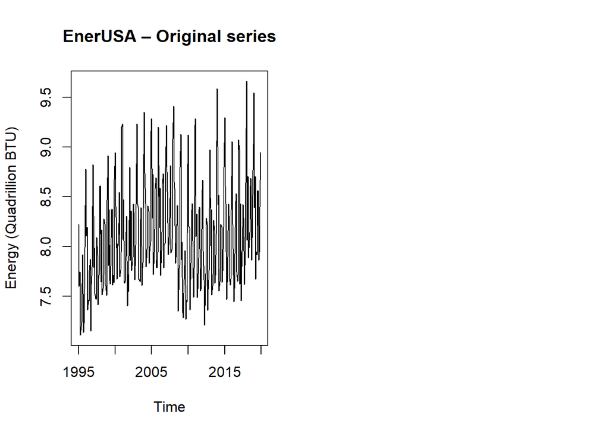

```r
serie_EnerUSA=ts(read.table("datasets/EnerUSA.dat", header=F)/1000,start=1995,freq=12)

# QUESTION 11 JUSTIFICATION
par(mfrow = c(1,2))
plot(serie_EnerUSA,
     main = "EnerUSA – Original series",
     ylab = "Energy (Quadrillion BTU)", xlab = "Time")
nblock=10
idx=cut(seq_along(serie_EnerUSA), nblock, labels = FALSE)
m=tapply(serie_EnerUSA, idx, mean)
s=tapply(serie_EnerUSA, idx, sd)
print(data.frame(Block = 1:nblock,
                 Mean  = round(m, 3),
                 SD    = round(s, 3),
                 ratio = round(m,3)/round(s,3)))
```

##### 12) By looking at the ACF/PACF of the seasonally and regularly-differenced series, an MA model can be clearly identified for the seasonal part, and another MA model for the regular part.

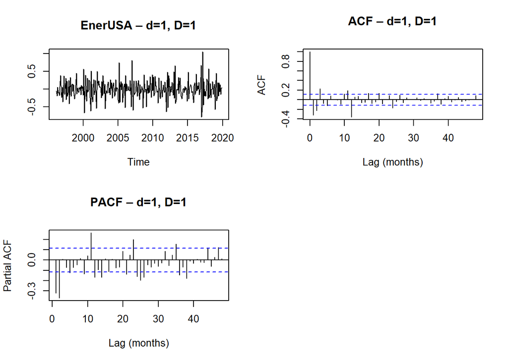

```r
# QUESTION 12 JUSTIFICATION
d12=diff(serie_EnerUSA, lag = 12)
d1d12=diff(d12, lag = 1)

par(mfrow = c(2,2))
plot(d1d12,
     main = "EnerUSA – d=1, D=1",
     ylab = "", xlab = "Time")
acf(as.numeric(d1d12),  lag.max = 48, main = "ACF – d=1, D=1",
    xlab = "Lag (months)")
pacf(as.numeric(d1d12), lag.max = 48, main = "PACF – d=1, D=1",
     xlab = "Lag (months)")
par(mfrow = c(1,1))
```

```r
ac <- acf(d1d12, lag.max = 48, plot = FALSE)
cat("ACF at lag 1: ",  round(ac$acf[2],  3), "\n")
```

```
## ACF at lag 1:  -0.321
```

```r
cat("ACF at lag 12:", round(ac$acf[13], 3), "\n")
```

```
## ACF at lag 12: -0.36
```

```r
cat("ACF at lag 24:", round(ac$acf[25], 3), "\n")
```

```
## ACF at lag 24: -0.172
```

##### 13) The ARIMA(0,1, 2)(0,1,2)12 model yields better punctual predictions for the last 12 observations than the ARIMA(3,0,0)(0,1,3)12 model with an intercept.

```r
# QUESTION 13 JUSTIFICATION
fit13a=arima(serie_EnerUSA, order = c(0,1,2),
                seasonal = list(order = c(0,1,2), period = 12))
fit13b=arima(serie_EnerUSA, order = c(3,0,0),
                seasonal = list(order = c(0,1,3), period = 12),
                include.mean = TRUE)

cat("ARIMA(0,1,2)(0,1,2)12: \n"); coeftest(fit13a)
```

```
## ARIMA(0,1,2)(0,1,2)12:
```

```
##
## z test of coefficients:
##
##       Estimate Std. Error  z value Pr(>|z|)
## ma1  -0.509984   0.061112  -8.3451  < 2e-16 ***
## ma2  -0.152530   0.066962  -2.2779  0.02273 *
## sma1 -0.760754   0.071804 -10.5948  < 2e-16 ***
## sma2 -0.145538   0.073728  -1.9740  0.04838 *
## ---
## Signif. codes:  0 '***' 0.001 '**' 0.01 '*' 0.05 '.' 0.1 ' ' 1
```

```r
cat("AIC:", AIC(fit13a), "| BIC:", BIC(fit13a), "\n")
```

```
## AIC: -145.8512 | BIC: -127.5538
```

```r
cat("ARIMA(3,0,0)(0,1,3)12 + intercept: \n"); coeftest(fit13b)
```

```
## ARIMA(3,0,0)(0,1,3)12 + intercept:
```

```
##
## z test of coefficients:
##
##       Estimate Std. Error  z value  Pr(>|z|)
## ar1   0.468964   0.057396   8.1707 3.065e-16 ***
## ar2   0.127177   0.066482   1.9130  0.055753 .
## ar3   0.252887   0.058492   4.3234 1.536e-05 ***
## sma1 -0.775314   0.068705 -11.2847 < 2.2e-16 ***
## sma2 -0.204578   0.063196  -3.2372  0.001207 **
## sma3  0.208002   0.075197   2.7661  0.005673 **
## ---
## Signif. codes:  0 '***' 0.001 '**' 0.01 '*' 0.05 '.' 0.1 ' ' 1
```

```r
cat("AIC:", AIC(fit13b), "| BIC:", BIC(fit13b), "\n")
```

```
## AIC: -157.2931 | BIC: -131.6524
```

### APB: Mercantile Activity in the Port of Barcelona

##### 14) The forecasts from the ARIMA (0,1,1)(0,1,1)12 model for the last year are correct.

**Answer**: *TRUE*. This question has been answered based on splitting the data in a train and a test set, fitting a model and predicting the test set. The evaluation has been based on the number of predicted values that remain outside of the 95% CI. As in the selected test set there are not values falling out the CI, we can assume the forecasts are correct.

```r
serie_APB=window(ts(read.table("datasets/apb.dat")[,1]/1000,start=1997,freq=12),start=2000)

# QUESTION 14 JUSTIFICATION
# Fit model on all data except last 12 observations
n=length(serie_APB)
train=window(serie_APB, end   = time(serie_APB)[n - 12])
test=window(serie_APB, start = time(serie_APB)[n - 11])
fit14=arima(train, order = c(0,1,1),
               seasonal = list(order = c(0,1,1), period = 12))
pred14=forecast(fit14, h = 12)
actual <- as.numeric(test)
lo95   <- as.numeric(pred14$lower[, 2])
hi95   <- as.numeric(pred14$upper[, 2])
cat("Values outside 95% CI:", sum(actual < lo95 | actual > hi95), "out of 12\n")
```

```
## Values outside 95% CI: 0 out of 12
```

##### 15) The Ljung-Box statistics for the previous model have p-values greater than 0.05 for all the lags, which implies that the model is valid.

**Answer**: *FALSE*. As it can be seen in the results table, the p-value for some of the lags is lower than 0.05.

```r
# QUESTION 15 JUSTIFICATION
# Ljung-Box at several lags
lags  <- c(2,4,6,8,10,12,18,24,36)
lb_df <- data.frame(
  Lag     = lags,
  p_value = sapply(lags, function(l)
              round(Box.test(residuals(fit14), lag = l,
                             type = "Ljung-Box", fitdf = 2)$p.value,   4))
)
print(lb_df)
```

```
##   Lag p_value
## 1   2  0.0000
## 2   4  0.0965
## 3   6  0.2064
## 4   8  0.4275
## 5  10  0.5961
## 6  12  0.7308
## 7  18  0.0135
## 8  24  0.0049
## 9  36  0.0166
```